# Logistic Regression Model

Group #6

This page presents an exploration of survival status outcomes based on the analysis of patient data using Logistic Regression with different feature selection strategies. Dropping less significant features can avoid overfitting and reduce computational complexity and improve model reliability.

## Data Preparation

The dataset we are using in this analysis are the filtered and scaled version of the original dataset, we first scaled all continues variables, and then set the landmark at 1000, drop all cid=0 to prevent issues of the unbalance dataset will bring to the prediction model.

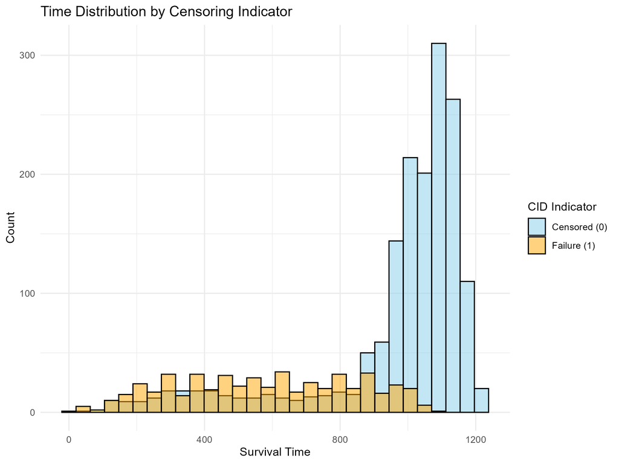

Original Dataset:

| Dataset | Cid= 0 | Cid= 1 |
| --- | --- | --- |
| Original Dataset | 1627 | 521 |
| Modified Dataset | 503 | 503 |

## Initial Model and Performance

The initial logistic regression model used all 22 features and target variable `cid`, which is the status of patients. We split the dataset into training and testing sets with 7:3 ratio.

This model achieved an accuracy of **72%** on the test set and demonstrated strong discriminatory ability, significant predictors identified in the model included age, hemoglobin levels `hemo`, drug use `drugs`, and pre-antiretroviral treatment status `preanti`, among others.

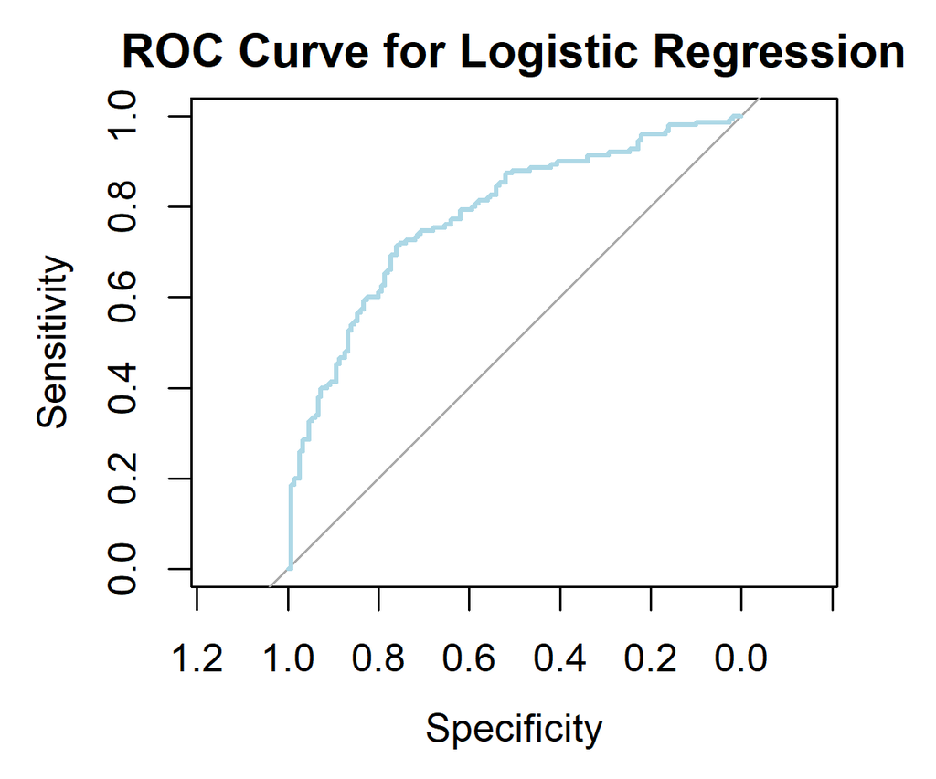

The Initial mode has an AUC value of **0.7812**.

### fit with selected features with P<0.05

We choose features with p<0.05 and used them on the refine model. The refined model has an accuracy of **71%**, lower than the original model, thus we reject this model.

## Lasso Regression

We employed the Lasso regression to enhance feature selection and improve model interpretability.

The Lasso regression applies L1 penalty, set less relevant features with a coefficient of 0. Using cross-validation, the optimal penalty parameter (lambda) was determined to be the value that minimized the cross-validated error. The features we choosed using lasso regression are `offtrt`, `cd420`, `race`, `symptom`, `drugs`,`treat`, `cd820`, `strat`.

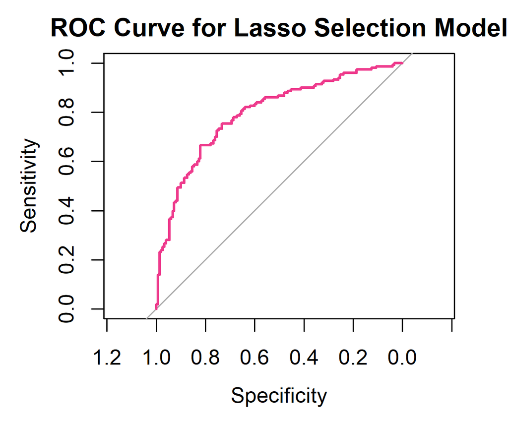

The Lasso model has a better performance than the initial logistic regression model with better discriminative power.

## Backward Selection

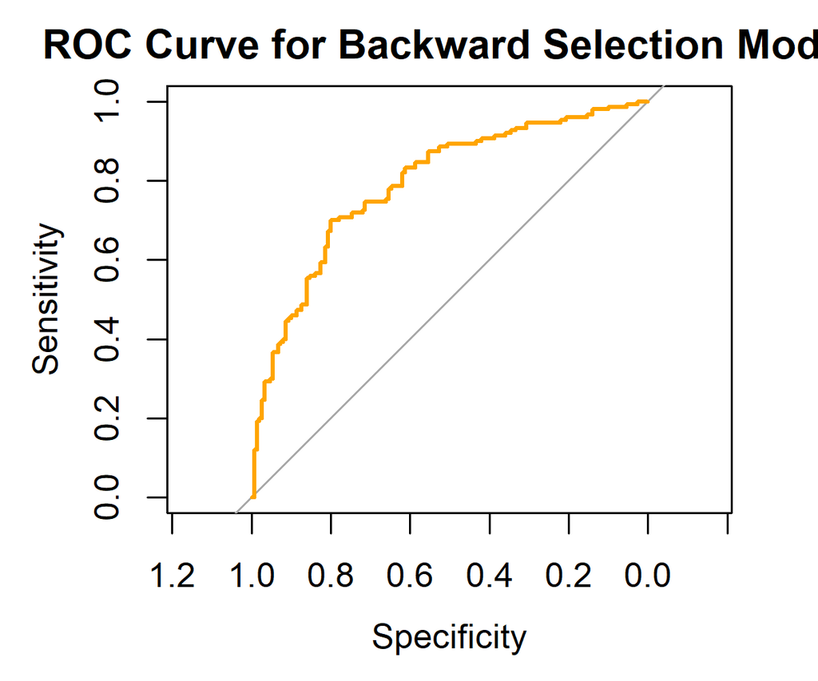

The model also has an AUC value of **0.7924**.

## Conclusion

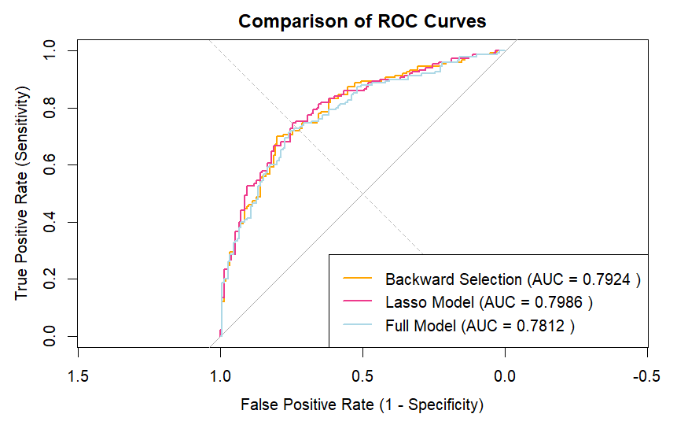

| Predictor | Coefficient | p-value |
| --- | --- | --- |
| (Intercept) | 3.47756 | 0.018162 * |
| karnof | -0.03901 | 0.010080 * |
| symptom | 0.58024 | 0.014384 * |
| treat | -0.68194 | 0.000907 *** |
| offtrt | 1.23530 | 1.12e-09 *** |
| cd420 | -1.09290 | < 2e-16 *** |
| cd80 | 0.13870 | 0.124861 |

The Lasso has a confusion matrix of this:

[output not shown]

The lasso balanced the predictive power and feature selection through regularization with better AUC. while backward selection giving a slightly less complex model with better accuracy. The confusion matrix also validate the accuracy was not affected by the high ratio between cid=1 and cid =0 as we filtered the data earlier.